# Team02-24Feb2026

Author

Xinghan Shen, Alexander Lim, Jessica Xiong, Neha Maqsood, John Saleeb

```r
#if (!require("Synth"))     install.packages("Synth")
#if (!require("synthdid"))  install.packages("synthdid")
#if (!require("grf"))       install.packages("grf")
#if (!require("ranger"))    install.packages("ranger")
#if (!require("gridExtra")) install.packages("gridExtra")
#install.packages("devtools")
#devtools::install_github("synth-inference/synthdid")

# Load package(s)

library(tidyverse)
library(lubridate)
library(splines)
library(readr)
library(MatchIt)
library(dplyr)
library(broom)
library(cobalt)
library(tableone)
library(ggplot2)
library(corrplot)
library(lmtest)
library(sandwich)
library(Synth)
library(synthdid)
library(grf)
library(ranger)
library(gridExtra)
```

## Introduction

We are a data science consulting firm specializing in healthcare policy innovation and impact analysis. We are experts when it comes to modern machine learning and econometric modeling to improve nurse retention outcomes and hospital policies. Data-driven decision-making for these large institutions that play such a significant role in the lives of numerous humans has never been more important.

Our client is a Southern California-based hospital network Optum that operates just over 50 hospitals. Since the pandemic, the network has noticed that hospital attrition has been rising up significantly. High turnover for the nursing staff has not only affected the network financially because of the training costs, but also the patients at the core of their mission. Operational strain has run its full course. To respond, Optum now has two promotions to help retain nurses. The first is a seniority bonus for nurses who have been with the organization for more than 10 years. The second is a management training program that allows for the hospitals to train these nurses, spurring job growth over time.

## Summary

### Question Posed By The Client

The questions posed by the client is:

1. What was the causal impact of seniority bonuses and the management training program on nurse attrition?
2. How did the attrition change at treated hospitals relative to the untreated hospitals over time?
3. Do these policies work equally well for all sub-groups or do they help some subgroups other than others?

### DAG

Our outcome variable (Y) is the binary variable nurse attrition. The treatment variables (D1, D2) are the seniority bonuses eligibility and exposure to management training for the nurses. The observed covariates are age, tenure, education, and hospital characteristics (region, bed size, for-profit/non-profit). The unobserved variable is nurse resilience. This affects both retention for nurses and treatment take-up. Under this overall scenario, we enter with the assumption that a treated hospital will have similar trends to comparable hospitals based on the characteristics described above.

### Methods Used We employed a three-stage methodological approach:

We employ three advanced econometric techniques as prescribed in the course curriculum:

1. Synthetic Control (SC): We are able to visually and quantitatively estimate hospital-level effects by constructing a synthetic counterfactual hospital for early adopters of the management nursing program.
2. Synthetic Difference-in-Differences (SDID): This allows us to estimate the average treatment effect on comparable hospitals while having light parallel assumptions. We are able to strengthen the argument for causal credibility with SDID by making small DID adjustments and improving robustness to subpar pre-trends.
3. Causal Random Forest (HTE): SC and SDID provide us with ways to look at average effects. HTE allows us to answer our third question and understand who benefits the most from the programs implemented. We are able to calculate conditional average treatment effects (CATEs) and nurse-level heterogeneity in response to different variables (e.g. age, education, tenure).

## Data Simulation

### Target Variable and Distribution

Target variable: attrition (0/1), representing whether a nurse leaves in a given time period.

Distributional choice: We simulate attrition at the nurse-month level as a Bernoulli random variable whose probability is generated by a logistic model.

How the probability is generated (plain text version):

1. We first construct a “risk score” (a linear index) as an additive function of:
   1. hospital baseline differences (some hospitals have systematically higher attrition)
   2. common time shocks (system-wide waves that affect all hospitals)
   3. hospital-specific trends (pre-trend differences across hospitals)
   4. observed nurse covariates (age, tenure, education)
   5. observed hospital covariates (bed size, region, for-profit)
   6. unobserved resilience (affects both attrition and treatment take-up)
   7. treatment effects from the bonus program and the management training program
   8. heterogeneous effect where training works better for a subgroup (example: mid-career nurses)
2. Then we transform the risk score into a probability using the logistic function:

   p = 1 / (1 + exp(-risk_score))
3. Finally:

   attrition ~ Bernoulli(p) via rbinom(1, 1, p)

Why this choice is appropriate:

1. Attrition is naturally binary.
2. The logistic probability guarantees valid values between 0 and 1.
3. The nurse-level outcome can be aggregated into hospital-level attrition rates, which is the required input format for Synthetic Control and Synthetic DiD.

### Defining the Distribution of the Treatment Variables

We simulate two treatments that match the client’s policies and our DAG.

#### Treatment 1: Seniority Bonus exposure (`D_bonus`)

1. Eligibility is determined by tenure:

   `bonus_eligible = 1 if tenure >= 10 else 0`
2. The bonus becomes active network-wide after a policy start period `t0_bonus`
3. Exposure is:

```
`D_bonus = 1 if (t >= t0_bonus AND tenure >= 10) else 0`
```

**Justification:**

1. Eligibility is rule-based and determined by tenure.
2. Exposure begins only after the policy is rolled out.

#### Treatment 2: Management training adoption (`D_train`)

1. This is a hospital-level program with staggered adoption:
   1. some hospitals never adopt
   2. some adopt earlier than others
2. Adoption probability depends on hospital strain and size, larger, higher-strain hospitals are more likely to adopt
3. Adoption timing depends on strain, higher-strain hospitals adopt earlier on average
4. Treatment indicator: D_train = 1 if t >= adopt_time[hospital] else 0

Justification:

1. Hospitals under operational pressure are more likely to implement retention-oriented programs.
2. Staggered adoption supports both SC (single treated unit vs donor pool) and SDID (ATT across treated units with better robustness than vanilla DID).

### Defining the Distribution of other elements in our DAG

Observed covariates

Hospital-level:

1. `bed_size`: log-normal (right-skewed, realistic)
2. `region`: categorical (Metro / Coastal / Inland)
3. `for_profit`: Bernoulli

Nurse-level:

1. age: truncated normal (bounded to realistic working ages)
2. tenure: correlated with age + noise (bounded to 0–35 years)
3. education: categorical (ADN / BSN / MSNplus), probabilities vary by region

Unobserved confounder

1. `resilience`: Normal(0,1) with a small shift by hospital strain
2. It reduces attrition, and hospitals with higher strain tend to have slightly lower resilience on average

Justification:Resilience is plausibly related to both retention and how effectively a hospital can implement or benefit from programs, matching our DAG assumption that some confounding remains unobserved.

### Code

```r
library(tidyverse)
library(lubridate)
set.seed(123)
# 1) Global design choices

H <- 52
Tt <- 36
start_date <- ymd("2021-01-01")
dates <- start_date %m+% months(0:(Tt-1))
t0_bonus <- 13               # starts at month 13
nurses_per_h <- rpois(H, lambda = 260) + 120

# 2) Hospital-level variables
hospitals <- tibble(
  hospital_id = 1:H,
  region = sample(c("Metro", "Coastal", "Inland"), H, replace = TRUE,
                  prob = c(0.45, 0.35, 0.20)),
  for_profit = rbinom(H, 1, 0.35),
  bed_size = round(exp(rnorm(H, mean = log(220), sd = 0.45)))) %>%
mutate(strain = as.numeric(scale(0.35*log(bed_size) + 0.25*for_profit + rnorm(H, 0, 1))),alpha_h = rnorm(H, mean = 0, sd = 0.45),phi_h   = rnorm(H, mean = 0, sd = 0.03) + 0.015*strain
  )
# 3) Traing program adoption (staggered)
adopt_prob <- plogis(-0.4 +
                       0.9*as.numeric(scale(hospitals$strain)) +
                       0.25*as.numeric(scale(log(hospitals$bed_size))))
hospitals <- hospitals %>%
mutate(adopt = rbinom(H, 1, adopt_prob),adopt_time = if_else(adopt == 1,pmax(8, pmin(28, round(22 - 5*as.numeric(scale(strain)) + rnorm(H, 0, 2)))),NA_real_))

# 4) Nurse-level baseline covariates
nurse_frame <- map_dfr(1:H, function(h) {
  n_h <- nurses_per_h[h]
  # Education distribution varies slightly by region
  edu_probs <- case_when(
    hospitals$region[h] == "Metro"   ~ list(c(0.30, 0.55, 0.15)),
    hospitals$region[h] == "Coastal" ~ list(c(0.35, 0.52, 0.13)),
    TRUE                            ~ list(c(0.42, 0.50, 0.08))
  ) %>% unlist()
  education <- sample(c("ADN", "BSN", "MSNplus"),
                      n_h, replace = TRUE, prob = edu_probs)
  age_raw <- rnorm(n_h, mean = 37, sd = 9)
  age <- pmin(pmax(age_raw, 22), 62)
  tenure_raw <- 0.65*(age - 22) + rnorm(n_h, 0, 5)
  tenure <- pmin(pmax(tenure_raw/2, 0), 35)
  # Unobserved resilience
  resilience <- rnorm(n_h, mean = -0.15*hospitals$strain[h], sd = 1)
  tibble(
    hospital_id = h,
    nurse_id = paste0("H", h, "_N", 1:n_h),
    age = age,
    tenure = tenure,
    education = factor(education, levels = c("ADN", "BSN", "MSNplus")),
    resilience = resilience)})
# 5) Time index and common shocks
time_df <- tibble(t = 1:Tt, date = dates) %>%
  mutate(lambda_t = 0.18*exp(-(t-1)/18) + 0.06*sin(2*pi*t/12)
  )

# 6) Build nurse-time panel, treatments, and attrition outcome
nurse_panel <- nurse_frame %>%
  crossing(time_df) %>%
  left_join(
    hospitals %>% select(hospital_id, region, for_profit, bed_size, strain, alpha_h, phi_h, adopt_time),
    by = "hospital_id"
  ) %>%
  mutate(
    # Treatment 1: Seniority bonus exposure
    bonus_eligible = as.integer(tenure >= 10),
    D_bonus = as.integer(t >= t0_bonus) * bonus_eligible,

    # Treatment 2: Hospital training program exposure
    D_train = if_else(!is.na(adopt_time) & t >= adopt_time, 1L, 0L),

    mid_career = as.integer(tenure >= 5 & tenure < 15),
    edu_BSN = as.integer(education == "BSN"),
    edu_MSN = as.integer(education == "MSNplus"),
    risk_score =
      -2.2 +
      alpha_h + lambda_t + phi_h*(t-1) +
      0.020*(age - 35) +
      -0.045*(tenure) +
      -0.12*edu_BSN - 0.22*edu_MSN +
      0.18*strain +
      -0.35*resilience +
      (-0.30)*D_bonus +
      (-0.25)*D_train +
      (-0.10)*D_train*mid_career,
    p_attrit = 1 / (1 + exp(-risk_score)),
    attrition = rbinom(n(), 1, p_attrit))


# 7) Aggregate to hospital-time panel (for SC/SDID)
hospital_panel <- nurse_panel %>%
  group_by(hospital_id, t, date) %>%
  summarise(
    attrition_rate = mean(attrition),
    D_train = max(D_train),
    adopt_time = suppressWarnings(max(adopt_time, na.rm = TRUE)),
    bed_size = first(bed_size),
    region = first(region),
    for_profit = first(for_profit),
    strain = first(strain),
    .groups = "drop"
  )


summary(hospital_panel$attrition_rate)
```

```
    Min.  1st Qu.   Median     Mean  3rd Qu.     Max.
0.002652 0.048309 0.077217 0.098080 0.121004 0.670984
```

```r
table(hospitals$adopt, useNA = "ifany")
```

```
 0  1
30 22
```

## Visuals Code

We begin by exploring the structure of the simulated panel data to understand treatment timing, baseline comparability across hospitals, and potential heterogeneity in attrition. These exploratory figures help inform our methodological choices for Synthetic Control, Synthetic Difference-in-Differences (SDiD), and heterogeneous treatment effect (HTE) estimation.

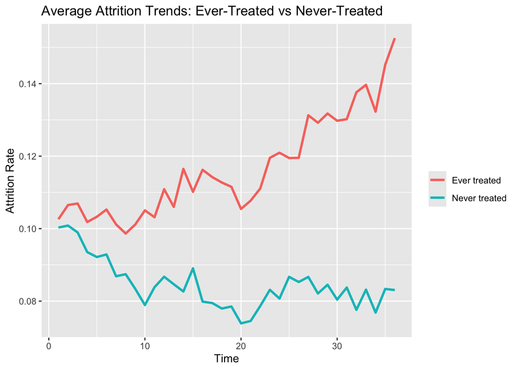

```r
# Identify hospitals that ever adopt training
ever_train <- hospital_panel %>%
  group_by(hospital_id) %>%
  summarise(ever_train = as.integer(any(D_train == 1)), .groups = "drop")

hp2 <- hospital_panel %>%
  left_join(ever_train, by = "hospital_id") %>%
  mutate(group = if_else(ever_train == 1, "Ever treated", "Never treated"))

avg_trends <- hp2 %>%
  group_by(t, group) %>%
  summarise(attrition_rate = mean(attrition_rate), .groups = "drop")

ggplot(avg_trends, aes(x = t, y = attrition_rate, color = group)) +
  geom_line(size = 1.1) +
  labs(title = "Average Attrition Trends: Ever-Treated vs Never-Treated",
       x = "Time", y = "Attrition Rate", color = "")
```

This graph shows that hospitals that eventually adopt training have consistently higher attrition rates than hospitals that never adopt. This difference exists even before training adoption, suggesting systematic baseline differences between treated and control hospitals. The divergence in levels indicates that a simple comparison of treated and untreated hospitals would be biased. This motivates the use of reweighting approaches such as Synthetic Control and SDiD to construct better counterfactuals.

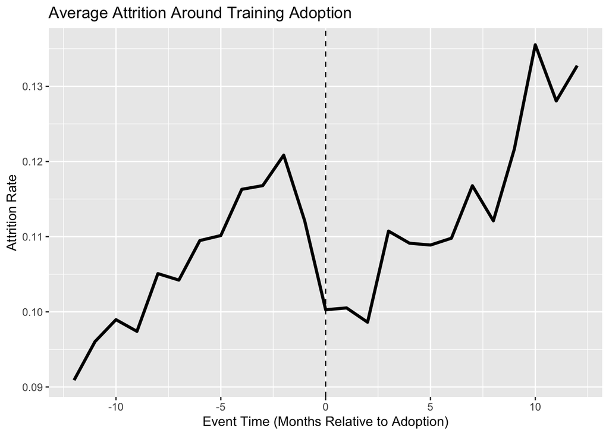

```r
# Compute event time relative to first training
train_time <- hospital_panel %>%
  filter(D_train == 1) %>%
  group_by(hospital_id) %>%
  summarise(first_train = min(t), .groups = "drop")

hp_event <- hospital_panel %>%
  left_join(train_time, by = "hospital_id") %>%
  mutate(event_time = t - first_train)

event_avg <- hp_event %>%
  filter(!is.na(event_time), event_time >= -12, event_time <= 12) %>%
  group_by(event_time) %>%
  summarise(attrition_rate = mean(attrition_rate), .groups = "drop")

ggplot(event_avg, aes(x = event_time, y = attrition_rate)) +
  geom_line(size = 1.2) +
  geom_vline(xintercept = 0, linetype = "dashed") +
  labs(title = "Average Attrition Around Training Adoption",
       x = "Event Time (Months Relative to Adoption)",
       y = "Attrition Rate")
```

This graph plots average attrition relative to the month of training adoption. Attrition appears to increase in the periods leading up to adoption, suggesting that hospitals may implement training in response to rising attrition. A small dip occurs around the adoption period itself, which may reflect short-run adjustments or noise from averaging across hospitals with different adoption timings. Following adoption, attrition trends continue to evolve. Overall, the presence of pre-treatment dynamics indicates that treated hospitals were already on different trajectories prior to adoption. This suggests that standard DiD assumptions may be violated and supports the use of Synthetic Control and SDiD methods that explicitly adjust for pre-treatment trends.

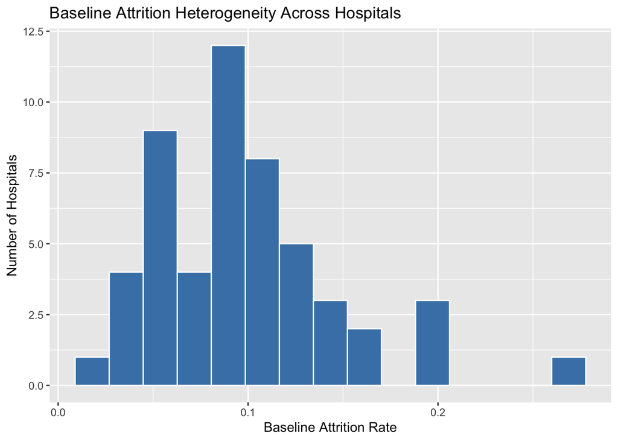

```r
baseline_attr <- hospital_panel %>%
  filter(t <= 6) %>%
  group_by(hospital_id) %>%
  summarise(baseline_attrition = mean(attrition_rate), .groups = "drop")

ggplot(baseline_attr, aes(x = baseline_attrition)) +
  geom_histogram(bins = 15, fill = "steelblue", color = "white") +
  labs(title = "Baseline Attrition Heterogeneity Across Hospitals",
       x = "Baseline Attrition Rate",
       y = "Number of Hospitals")
```

Baseline attrition varies substantially across hospitals, indicating meaningful heterogeneity in hospital environments and workforce dynamics. This suggests that the impact of training may differ across hospitals, motivating heterogeneous treatment effect analysis.

```r
hospital_panel %>%
  group_by(region) %>%
  summarise(avg_attrition = mean(attrition_rate))
```

```
# A tibble: 3 × 2
  region  avg_attrition
  <chr>           <dbl>
1 Coastal        0.108
2 Inland         0.0761
3 Metro          0.0969
```

```r
hospital_panel %>%
  group_by(D_train) %>%
  summarise(avg_attrition = mean(attrition_rate))
```

```
# A tibble: 2 × 2
  D_train avg_attrition
    <int>         <dbl>
1       0        0.0875
2       1        0.139
```

The first table summarizes average attrition rates by region. Attrition appears highest in coastal hospitals (10.8%), followed by metro hospitals (9.69%), and lowest in inland hospitals (7.61%). These differences suggest that geographic context may influence workforce dynamics and turnover pressures. Regional variation in labor markets, cost of living, and staffing conditions could contribute to these disparities. Because attrition levels differ systematically across regions, treatment effects may also vary geographically.

The second table reports average attrition rates by training status. Hospitals that implement training exhibit substantially higher attrition (13.9%) compared to hospitals without training (8.75%). However, this difference should not be interpreted causally. The EDA suggests that hospitals adopting training already had higher attrition prior to adoption, indicating potential selection into treatment. Therefore, the raw difference likely reflects pre-existing differences rather than the true causal impact of training. This motivates the use of Synthetic Control and SDiD methods to construct appropriate counterfactuals.

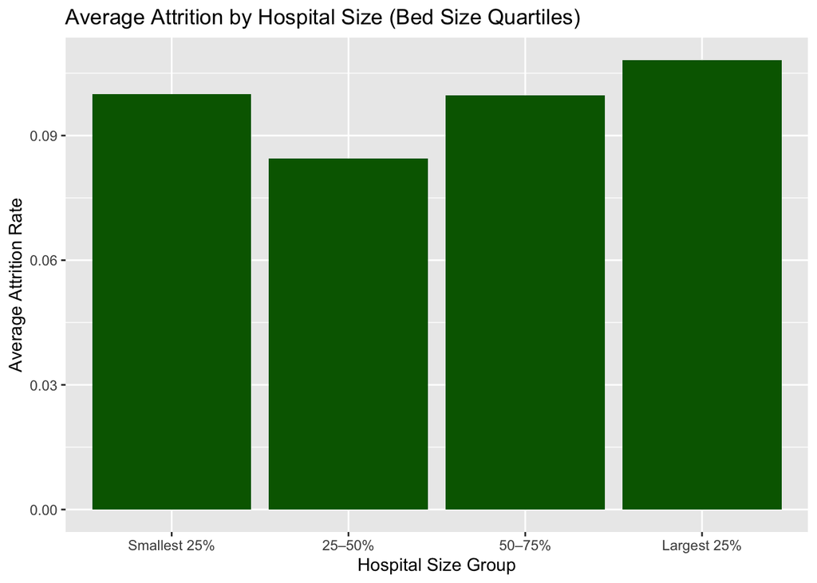

```r
library(dplyr)
library(ggplot2)

hp_size <- hospital_panel %>%
  group_by(hospital_id) %>%
  summarise(
    bed_size = first(bed_size),
    avg_attrition = mean(attrition_rate),
    .groups = "drop"
  ) %>%
  mutate(size_bin = ntile(bed_size, 4)) %>%
  mutate(size_bin = factor(size_bin,
                           levels = 1:4,
                           labels = c("Smallest 25%", "25–50%", "50–75%", "Largest 25%")))

size_plot <- hp_size %>%
  group_by(size_bin) %>%
  summarise(mean_attrition = mean(avg_attrition), .groups = "drop")

ggplot(size_plot, aes(x = size_bin, y = mean_attrition)) +
  geom_col(fill = "darkgreen") +
  labs(title = "Average Attrition by Hospital Size (Bed Size Quartiles)",
       x = "Hospital Size Group",
       y = "Average Attrition Rate")
```

Larger hospitals exhibit slightly higher attrition on average, suggesting that hospital size may influence workforce dynamics and treatment effects. This pattern supports examining heterogeneous treatment effects across hospital size groups.

## Influencing our methods

Synthetic Control (SC): The EDA reveals substantial baseline differences between hospitals that eventually adopt training and those that never adopt. In particular, ever-treated hospitals exhibit consistently higher attrition even before adoption and follow different pre-treatment trajectories. This suggests that a simple difference-in-means or standard DiD approach would be biased. To address this imbalance, we implement a Synthetic Control approach that constructs a weighted combination of control hospitals to match the treated hospital’s pre-treatment attrition path. This allows us to generate a more credible counterfactual for what would have happened to treated hospitals in the absence of training adoption.

Heterogeneous Treatment Effects (HTE): The EDA also shows meaningful heterogeneity across hospitals. Baseline attrition varies widely, and attrition differs by hospital size and region. These patterns suggest that the impact of training adoption may not be uniform across all hospitals. To account for this, we estimate heterogeneous treatment effects by examining whether treatment impacts differ across hospital characteristics such as size, region, and baseline attrition levels. This allows us to identify which types of hospitals benefit most (or least) from training adoption.

## Possible Suggestions from the EDA

The exploratory analysis suggests that hospitals adopting training tend to have higher attrition even prior to adoption, indicating potential selection into treatment. However, attrition trends appear to increase further after adoption, suggesting that training may be associated with changes in attrition dynamics. Because treated hospitals differ systematically from controls, causal methods that construct better counterfactuals are necessary. The patterns observed in the EDA motivate the use of Synthetic Control and SDiD to estimate the causal impact of training adoption, as well as heterogeneous treatment analysis to understand variation across hospital types. The next step is to formally estimate treatment effects and assess whether training reduces or increases attrition across different hospital settings.

## Methodology

This section presents the three econometric methods we deploy to answer Optum’s questions about nurse retention: Synthetic Control (SC), Synthetic Difference-in-Differences (SDiD), and Heterogeneous Treatment Effects (HTE) via Causal Random Forest and Meta-Learners. Each method is described non-technically first, followed by a detailed technical discussion of our specific implementation choices.

### 3.1 Synthetic Control (SC)

#### Non-Technical Description

Synthetic Control asks: *“What would have happened to a high-attrition hospital’s nurse turnover rate if it had never adopted the management training program?”* Rather than comparing the treated hospital to a single control hospital — which may be a poor match — SC builds a weighted combination of untreated hospitals (the “donor pool”) whose pre-treatment attrition trajectory closely resembles the treated hospital’s. This weighted combination is the synthetic twin, or counterfactual. The gap between the treated hospital’s actual attrition and the synthetic hospital’s attrition is our estimated treatment effect over time.

#### Technical Implementation

We apply SC to the single earliest-adopting hospital — the hospital with the smallest adopt_time — which provides the longest post-treatment window for evaluation. The donor pool consists of all hospitals that never adopted the training program (adopt == 0). We implement SC using the Synth package, following the same approach as Abadie and Gardeazabal (2003) as taught in class.

The dataprep() function prepares the data matrices. We supply time-averaged hospital characteristics (bed_size, strain, for_profit) as predictors, and lagged values of the outcome variable (attrition_rate) at specific pre-treatment periods as special predictors. The synth() function then solves for optimal donor weights minimizing the pre-treatment mean squared prediction error (MSPE). We use method = “BFGS” consistent with the class approach.

We visualize results using path.plot() and gaps.plot(), and report synth.tab() for balance tables. For inference, we implement the in-space placebo test: we loop over each donor hospital and apply SC as if that hospital were treated, storing the resulting gap series. We plot all placebo gaps in gray and overlay the true treated hospital gap in black.

```r
library(Synth)

# Identify the earliest-adopting hospital (our single treated unit)
treated_hosp <- hospitals %>%
  filter(adopt == 1) %>%
  arrange(adopt_time) %>%
  slice(1) %>%
  pull(hospital_id)

# Donor pool: hospitals that never adopted
donor_hosps <- hospitals %>%
  filter(adopt == 0) %>%
  pull(hospital_id)

# Last pre-treatment period for the treated unit
T0_val <- hospitals %>%
  filter(hospital_id == treated_hosp) %>%
  pull(adopt_time) %>%
  as.integer() - 1

adopt_t <- T0_val + 1  # first treated period
mid_pre <- round(T0_val / 2)

# Subset panel to treated + donor hospitals
sc_panel <- hospital_panel %>%
  filter(hospital_id %in% c(treated_hosp, donor_hosps)) %>%
  arrange(hospital_id, t)

T_max <- max(sc_panel$t)

# dataprep: prepare matrices for Synth
dataprep.out <- dataprep(
  foo                   = as.data.frame(sc_panel),
  predictors            = c("bed_size", "strain", "for_profit"),
  predictors.op         = "mean",
  time.predictors.prior = 1:T0_val,
  special.predictors    = list(
    list("attrition_rate", 1,        "mean"),
    list("attrition_rate", mid_pre,  "mean"),
    list("attrition_rate", T0_val,   "mean")
  ),
  dependent             = "attrition_rate",
  unit.variable         = "hospital_id",
  time.variable         = "t",
  treatment.identifier  = treated_hosp,
  controls.identifier   = donor_hosps,
  time.optimize.ssr     = 1:T0_val,
  time.plot             = 1:T_max
)

# Run Synth optimizer
synth.out <- synth(data.prep.obj = dataprep.out, method = "BFGS")
```

```
X1, X0, Z1, Z0 all come directly from dataprep object.


****************
 searching for synthetic control unit


****************
****************
****************

MSPE (LOSS V): 0.006211246

solution.v:
 0.01120069 0.4071247 0.0326277 0.2079114 0.3332641 0.007871421

solution.w:
 4e-10 1.8e-09 9e-10 6e-10 1 6e-10 3e-10 8e-10 1e-09 5e-10 3e-10 3e-10 1e-09 8e-10 7e-10 2e-10 1e-10 1.3e-09 7e-10 2.2e-09 6e-10 2e-10 2e-10 2.8e-09 9e-10 7e-10 6e-09 1.1e-09 1e-09 4e-10
```

```r
# Summary tables
synth.tables <- synth.tab(dataprep.res = dataprep.out, synth.res = synth.out)

cat("=== Pre-Treatment Predictor Balance ===\n")
```

```
=== Pre-Treatment Predictor Balance ===
```

```r
print(synth.tables$tab.pred)
```

```
                         Treated Synthetic Sample Mean
bed_size                 408.000   511.000     217.067
strain                     2.755     1.803      -0.333
for_profit                 1.000     0.000       0.300
special.attrition_rate.1   0.249     0.238       0.100
special.attrition_rate.4   0.277     0.193       0.094
special.attrition_rate.7   0.256     0.193       0.087
```

```r
cat("\n=== Donor Hospital Weights ===\n")
```

```
=== Donor Hospital Weights ===
```

```r
print(synth.tables$tab.w)
```

```
   w.weights unit.names unit.numbers
1          0          1            1
2          0          2            2
6          0          6            6
7          0          7            7
9          1          9            9
12         0         12           12
17         0         17           17
18         0         18           18
19         0         19           19
22         0         22           22
27         0         27           27
28         0         28           28
29         0         29           29
30         0         30           30
```

[output cut: 16 more lines]

```r
cat("\n=== Predictor Importance (V weights) ===\n")
```

```
=== Predictor Importance (V weights) ===
```

```r
print(synth.tables$tab.v)
```

```
                         v.weights
bed_size                 0.011
strain                   0.407
for_profit               0.033
special.attrition_rate.1 0.208
special.attrition_rate.4 0.333
special.attrition_rate.7 0.008
```

[figure not shown]

```r
# Path Plot
path.plot(
  synth.res       = synth.out,
  dataprep.res    = dataprep.out,
  Ylab            = "Hospital Attrition Rate",
  Xlab            = "Month",
  Ylim            = c(0, 0.30),
  Legend          = c("Treated Hospital", "Synthetic Hospital"),
  Legend.position = "topright",
  tr.intake       = adopt_t
)
```

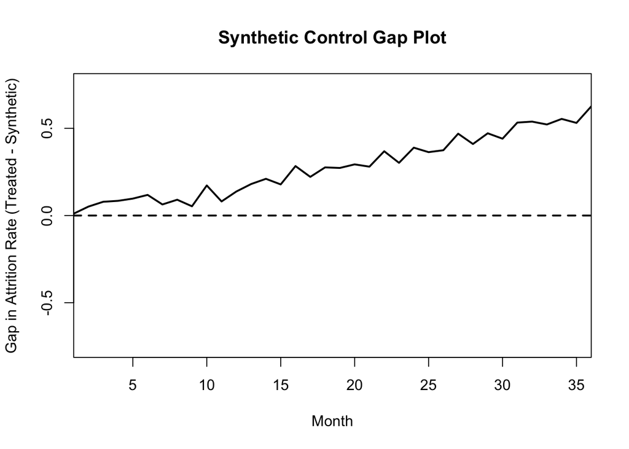

```r
# Gap Plot
gaps.plot(
  synth.res    = synth.out,
  dataprep.res = dataprep.out,
  Ylab         = "Gap in Attrition Rate (Treated - Synthetic)",
  Xlab         = "Month",
  Main         = "Synthetic Control Gap Plot"
)
```

```r
# Average post-treatment ATT
gaps_vec <- dataprep.out$Y1plot - (dataprep.out$Y0plot %*% synth.out$solution.w)
ATT_SC   <- mean(gaps_vec[(adopt_t):T_max])
cat("\n=== SC Average Post-Treatment ATT ===\n")
```

```
=== SC Average Post-Treatment ATT ===
```

```r
cat("ATT (SC):", round(ATT_SC, 5), "\n")
```

```
ATT (SC): 0.33189
```

```r
# Placebo Test: loop over all donor hospitals
store <- matrix(NA, nrow = T_max, ncol = length(donor_hosps))
colnames(store) <- paste0("H", donor_hosps)

for (iter in seq_along(donor_hosps)) {
  placebo_id   <- donor_hosps[iter]
  placebo_ctrl <- donor_hosps[-iter]

  tryCatch({
    dp_placebo <- dataprep(
      foo                   = as.data.frame(sc_panel),
      predictors            = c("bed_size", "strain", "for_profit"),
      predictors.op         = "mean",
      time.predictors.prior = 1:T0_val,
      special.predictors    = list(
        list("attrition_rate", 1,        "mean"),
        list("attrition_rate", mid_pre,  "mean"),
        list("attrition_rate", T0_val,   "mean")
      ),
      dependent             = "attrition_rate",
      unit.variable         = "hospital_id",
      time.variable         = "t",
      treatment.identifier  = placebo_id,
      controls.identifier   = placebo_ctrl,
      time.optimize.ssr     = 1:T0_val,
      time.plot             = 1:T_max
    )

    so_placebo <- synth(data.prep.obj = dp_placebo, method = "BFGS")
    store[, iter] <- dp_placebo$Y1plot - (dp_placebo$Y0plot %*% so_placebo$solution.w)
  }, error = function(e) NULL)
}
```

[output not shown]

[output cut: 543 more lines]

[output not shown]

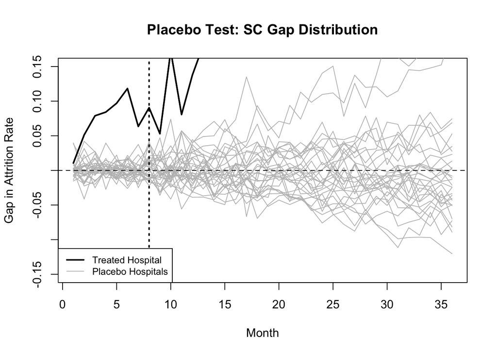

```r
# Placebo distribution plot
pre_mspe_treated  <- mean(gaps_vec[1:T0_val]^2)
pre_mspe_placebos <- apply(store[1:T0_val, ], 2, function(x) mean(x^2, na.rm = TRUE))
keep_cols <- pre_mspe_placebos < 5 * pre_mspe_treated

plot(1:T_max, gaps_vec,
     type = "l", lwd = 2, col = "black",
     ylim = c(-0.15, 0.15),
     xlab = "Month",
     ylab = "Gap in Attrition Rate",
     main = "Placebo Test: SC Gap Distribution")

for (j in which(keep_cols)) {
  lines(1:T_max, store[, j], col = "gray", lwd = 1)
}

lines(1:T_max, gaps_vec, col = "black", lwd = 2)
abline(v = adopt_t, lty = "dotted", lwd = 2)
abline(h = 0, lty = "dashed")
legend("bottomleft",
       legend = c("Treated Hospital", "Placebo Hospitals"),
       lty = 1, col = c("black", "gray"), lwd = c(2, 1), cex = 0.8)
```

```r
# Permutation p-value
post_mspe_treated  <- mean(gaps_vec[(adopt_t):T_max]^2)
post_mspe_placebos <- apply(store[(adopt_t):T_max, keep_cols], 2,
                             function(x) mean(x^2, na.rm = TRUE))
ratio_treated  <- post_mspe_treated  / pre_mspe_treated
ratio_placebos <- post_mspe_placebos / pre_mspe_placebos[keep_cols]

p_val_sc <- mean(ratio_placebos >= ratio_treated, na.rm = TRUE)
cat("SC Permutation p-value:", round(p_val_sc, 3), "\n")
```

```
SC Permutation p-value: 0.233
```

### 3.2 Synthetic Difference-in-Differences (SDiD)

#### Non-Technical Description

While SC focuses on a single treated hospital, Synthetic DiD (SDiD) extends the logic to multiple hospitals. SDiD simultaneously reweights both hospitals (unit weights) and time periods (time weights) so that the pre-treatment behavior of the control group closely mirrors the treated group. It then applies a DiD estimator on this reweighted panel, delivering a more robust ATT than standard DiD. Because synthdid requires simultaneous adoption, we focus on the largest adoption cohort and compare it to never-treated hospitals, which provides the cleanest 2x2 comparison.

#### Technical Implementation

We implement SDiD using the synthdid package. The method finds unit weights and time weights that minimize pre-treatment discrepancies, then estimates:

$$\hat{\tau}^{sdid} = \arg\min_{\tau,\mu,\alpha,\beta} \sum_{i,t} \hat{\omega}_i \hat{\lambda}_t \left(Y_{it} - \mu - \alpha_i - \beta_t - \tau D_{it}\right)^2$$

We select the largest adoption cohort so all treated units adopt simultaneously, satisfying the package requirement. Standard errors are computed via bootstrap.

```r
library(synthdid)

# synthdid requires simultaneous adoption
# Solution: pick the largest adoption cohort vs never-treated hospitals

adopt_cohort <- hospitals %>%
  filter(adopt == 1) %>%
  count(adopt_time) %>%
  arrange(desc(n)) %>%
  slice(1) %>%
  pull(adopt_time) %>%
  as.integer()

cat("Selected adoption cohort (month):", adopt_cohort, "\n")
```

```
Selected adoption cohort (month): 20
```

```r
# Hospitals in selected cohort
cohort_hosps <- hospitals %>%
  filter(adopt == 1, adopt_time == adopt_cohort) %>%
  pull(hospital_id)

# Never-treated hospitals
never_hosps <- hospitals %>%
  filter(adopt == 0) %>%
  pull(hospital_id)

cat("Treated hospitals in cohort:", length(cohort_hosps), "\n")
```

```
Treated hospitals in cohort: 3
```

```r
cat("Never-treated hospitals:", length(never_hosps), "\n")
```

```
Never-treated hospitals: 30
```

```r
# Subset panel to cohort + never-treated only
sdid_df <- hospital_panel %>%
  filter(hospital_id %in% c(cohort_hosps, never_hosps)) %>%
  select(hospital_id, t, attrition_rate, D_train) %>%
  arrange(hospital_id, t)

# Prepare panel matrices
pm <- panel.matrices(
  panel     = as.data.frame(sdid_df),
  unit      = "hospital_id",
  time      = "t",
  outcome   = "attrition_rate",
  treatment = "D_train"
)

cat("N0 (control units):", pm$N0, "\n")
```

```
N0 (control units): 30
```

```r
cat("T0 (pre-treatment periods):", pm$T0, "\n")
```

```
T0 (pre-treatment periods): 19
```

```r
# Estimate ATT via SDiD
set.seed(123)
tau.sdid <- synthdid_estimate(pm$Y, pm$N0, pm$T0)

# Bootstrap standard errors
se.sdid <- sqrt(vcov(tau.sdid, method = "bootstrap"))

cat("\n=== Synthetic DiD Results ===\n")
```

```
=== Synthetic DiD Results ===
```

```r
cat("Adoption Cohort (month):", adopt_cohort, "\n")
```

```
Adoption Cohort (month): 20
```

```r
cat("ATT Estimate           :", round(as.numeric(tau.sdid), 5), "\n")
```

```
ATT Estimate           : -0.00614
```

```r
cat("Bootstrap SE           :", round(se.sdid, 5), "\n")
```

```
Bootstrap SE           : 0.01293
```

```r
cat("95% CI: [",
    round(as.numeric(tau.sdid) - 1.96 * se.sdid, 5), ",",
    round(as.numeric(tau.sdid) + 1.96 * se.sdid, 5), "]\n")
```

```
95% CI: [ -0.03147 , 0.0192 ]
```

```r
cat("Z-statistic            :", round(as.numeric(tau.sdid) / se.sdid, 3), "\n")
```

```
Z-statistic            : -0.475
```

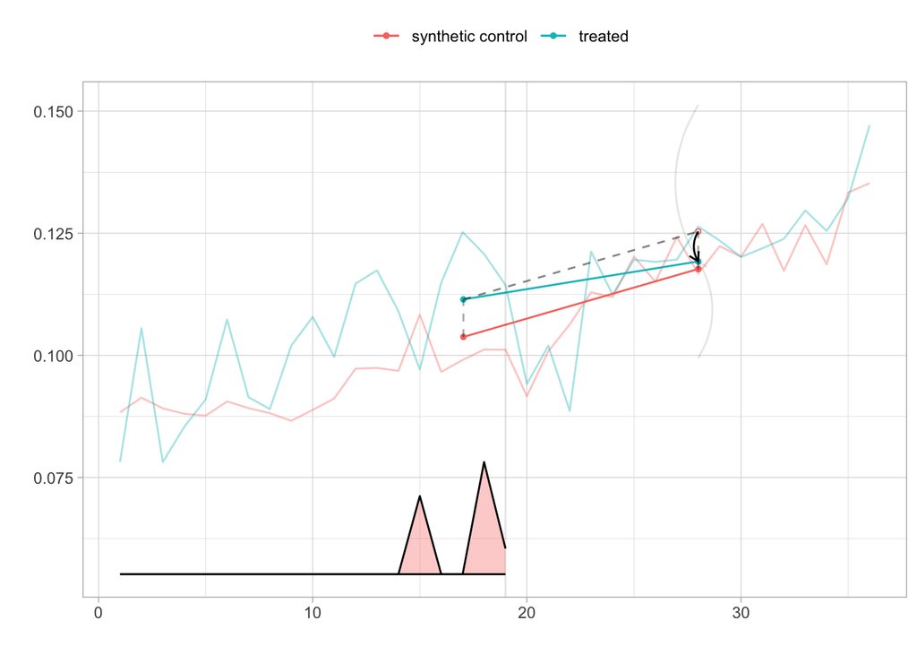

```r
# SDiD path plot
plot(tau.sdid)
```

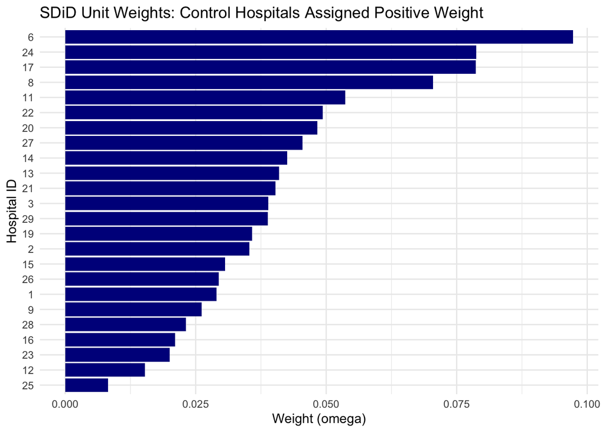

```r
# Unit weight distribution
omega_weights <- attr(tau.sdid, "weights")$omega
omega_df <- tibble(
  unit  = seq_along(omega_weights),
  omega = as.vector(omega_weights)
) %>%
  filter(omega > 0.005) %>%
  arrange(desc(omega))

ggplot(omega_df, aes(x = reorder(factor(unit), omega), y = omega)) +
  geom_col(fill = "darkblue") +
  coord_flip() +
  labs(
    title = "SDiD Unit Weights: Control Hospitals Assigned Positive Weight",
    x     = "Hospital ID",
    y     = "Weight (omega)"
  ) +
  theme_minimal()
```

```r
# Compare SC vs SDiD
comparison_tbl <- tibble(
  Method = c("Synthetic Control (SC)", "Synthetic DiD (SDiD)"),
  ATT    = round(c(ATT_SC, as.numeric(tau.sdid)), 5),
  SE     = c(NA, round(se.sdid, 5)),
  Note   = c("Single earliest-adopting hospital",
             paste("Cohort adopting at month", adopt_cohort, "vs never-treated"))
)
cat("\n=== Method Comparison: SC vs SDiD ===\n")
```

```
=== Method Comparison: SC vs SDiD ===
```

```r
print(comparison_tbl)
```

```
# A tibble: 2 × 4
  Method                      ATT      SE Note
  <chr>                     <dbl>   <dbl> <chr>
1 Synthetic Control (SC)  0.332   NA      Single earliest-adopting hospital
2 Synthetic DiD (SDiD)   -0.00614  0.0129 Cohort adopting at month 20 vs never-…
```

### 3.3 Heterogeneous Treatment Effects (HTE)

#### Non-Technical Description

SC and SDiD estimate average treatment effects. But Optum’s third question is: do these programs work equally well for all nurses? To answer this we estimate individual-level Conditional Average Treatment Effects (CATEs) as a function of each nurse’s characteristics. We deploy two classes of methods: the Causal Random Forest (CRF) and Meta-Learners (S-learner, T-learner, X-learner), allowing us to cross-validate findings and understand which subgroups benefit most.

#### Technical Implementation

The CRF uses the Robinson partial linear decomposition to residualize both outcome and treatment before fitting a forest targeting the CATE directly. We then extract ATE, CATE distribution, variable importance, and BLP. Meta-Learners use ranger random forests: S-learner trains one forest on all data, T-learner trains separate forests for treated and control groups, and X-learner refines with propensity score weighting. All methods operate at the nurse level using a cross-sectional snapshot from the post-adoption window.

```r
library(grf)

# Nurse-level cross-section: last period per nurse in post-adoption window
min_adopt <- hospitals %>%
  filter(adopt == 1) %>%
  pull(adopt_time) %>%
  min(na.rm = TRUE) %>%
  as.integer()

nurse_cs <- nurse_panel %>%
  filter(t >= min_adopt) %>%
  group_by(nurse_id) %>%
  slice_max(t, n = 1, with_ties = FALSE) %>%
  ungroup()

# Encode categorical variables
nurse_cs <- nurse_cs %>%
  mutate(
    edu_BSN     = as.integer(education == "BSN"),
    edu_MSN     = as.integer(education == "MSNplus"),
    reg_Metro   = as.integer(region == "Metro"),
    reg_Coastal = as.integer(region == "Coastal")
  )

# Define X, Y, W
X_vars <- c("age", "tenure", "edu_BSN", "edu_MSN",
            "reg_Metro", "reg_Coastal",
            "bed_size", "strain", "for_profit", "mid_career")

X <- as.matrix(nurse_cs[, X_vars])
Y <- nurse_cs$attrition
W <- nurse_cs$D_train

# Fit Causal Random Forest
set.seed(123)
fullsample.forest <- causal_forest(X, Y, W)
summary(fullsample.forest)
```

```
                         Length Class  Mode
_ci_group_size                1 -none- numeric
_num_variables                1 -none- numeric
_num_trees                    1 -none- numeric
_root_nodes                2000 -none- list
_child_nodes               2000 -none- list
_leaf_samples              2000 -none- list
_split_vars                2000 -none- list
_split_values              2000 -none- list
_drawn_samples             2000 -none- list
_send_missing_left         2000 -none- list
_pv_values                 2000 -none- list
_pv_num_types                 1 -none- numeric
predictions               19759 -none- numeric
variance.estimates            0 -none- numeric
debiased.error            19759 -none- numeric
excess.error              19759 -none- numeric
seed                          1 -none- numeric
num.threads                   1 -none- numeric
ci.group.size                 1 -none- numeric
X.orig                   197590 -none- numeric
Y.orig                    19759 -none- numeric
W.orig                    19759 -none- numeric
Y.hat                     19759 -none- numeric
W.hat                     19759 -none- numeric
clusters                      0 -none- numeric
equalize.cluster.weights      1 -none- logical
tunable.params                7 -none- list
has.missing.values            1 -none- logical
```

```r
# ATE
fullsample.ate <- average_treatment_effect(fullsample.forest, target.sample = "all")
cat("=== ATE (Causal Random Forest) ===\n")
```

```
=== ATE (Causal Random Forest) ===
```

```r
print(fullsample.ate)
```

```
estimate  std.err
     NaN       NA
```

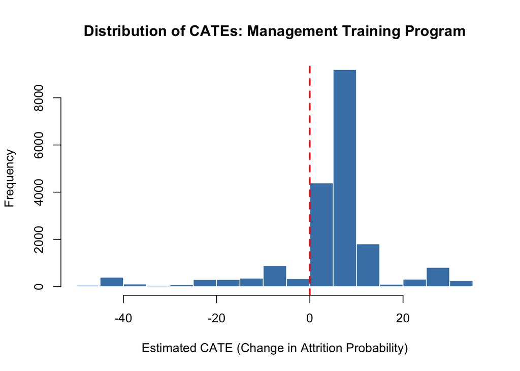

```r
# CATE distribution
CATE.FullSample <- predict(fullsample.forest)$predictions
hist(CATE.FullSample,
     main = "Distribution of CATEs: Management Training Program",
     xlab = "Estimated CATE (Change in Attrition Probability)",
     col  = "steelblue", border = "white")
abline(v = 0, lty = "dashed", col = "red", lwd = 2)
```

```r
# Feature importance
fullsample.varimp <- variable_importance(fullsample.forest)
ranked.vars <- order(fullsample.varimp, decreasing = TRUE)

cat("\n=== Top Features by Variable Importance ===\n")
```

```
=== Top Features by Variable Importance ===
```

```r
print(colnames(X)[ranked.vars])
```

```
 [1] "tenure"      "bed_size"    "age"         "strain"      "edu_BSN"
 [6] "for_profit"  "reg_Metro"   "edu_MSN"     "reg_Coastal" "mid_career"
```

```r
# Best Linear Projection
cat("\n=== Best Linear Projection (BLP) of CATE on Top Features ===\n")
```

```
=== Best Linear Projection (BLP) of CATE on Top Features ===
```

```r
blp_result <- best_linear_projection(fullsample.forest, X[, ranked.vars[1:5]])
print(blp_result)
```

```
Best linear projection of the conditional average treatment effect.
Confidence intervals are cluster- and heteroskedasticity-robust (HC3):

             Estimate Std. Error t value  Pr(>|t|)
(Intercept) -2.453798   9.431488 -0.2602  0.795653
tenure      -3.427742   1.168136 -2.9344  0.004782 **
bed_size     0.103402   0.022689  4.5575 2.719e-05 ***
age         -0.159472   0.423059 -0.3769  0.707587
strain       1.613948   2.342694  0.6889  0.493615
edu_BSN      0.391739   5.357712  0.0731  0.941965
---
Signif. codes:  0 '***' 0.001 '**' 0.01 '*' 0.05 '.' 0.1 ' ' 1
```

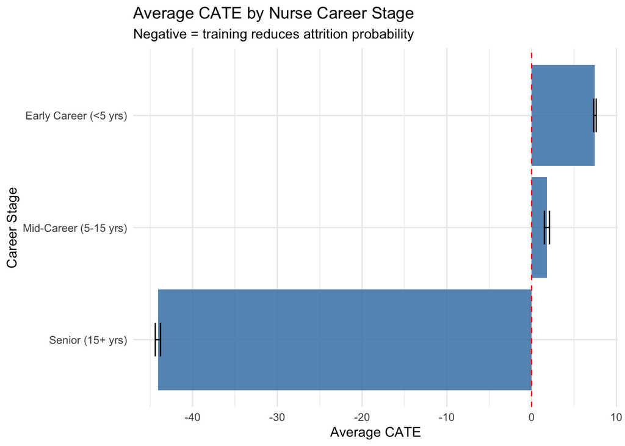

```r
# CATE by nurse subgroup
nurse_cs$cate <- CATE.FullSample

subgroup_cate <- nurse_cs %>%
  mutate(subgroup = case_when(
    mid_career == 1 ~ "Mid-Career (5-15 yrs)",
    tenure < 5      ~ "Early Career (<5 yrs)",
    tenure >= 15    ~ "Senior (15+ yrs)",
    TRUE            ~ "Other"
  )) %>%
  group_by(subgroup) %>%
  summarise(mean_cate = mean(cate),
            se_cate   = sd(cate) / sqrt(n()),
            n         = n(), .groups = "drop")

ggplot(subgroup_cate, aes(x = reorder(subgroup, mean_cate), y = mean_cate)) +
  geom_col(fill = "steelblue", alpha = 0.85) +
  geom_errorbar(aes(ymin = mean_cate - 1.96*se_cate,
                    ymax = mean_cate + 1.96*se_cate), width = 0.3) +
  geom_hline(yintercept = 0, linetype = "dashed", color = "red") +
  coord_flip() +
  labs(title = "Average CATE by Nurse Career Stage",
       subtitle = "Negative = training reduces attrition probability",
       x = "Career Stage", y = "Average CATE") +
  theme_minimal()
```

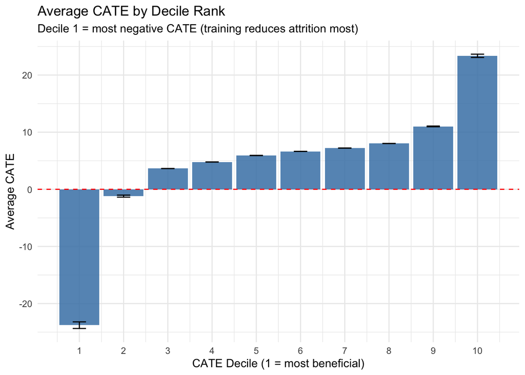

```r
# CATE by Quantile Ranking
nurse_cs$cate_rank <- ntile(CATE.FullSample, 10)

cate_by_rank <- nurse_cs %>%
  group_by(cate_rank) %>%
  summarise(mean_cate = mean(cate),
            se_cate   = sd(cate) / sqrt(n()),
            .groups   = "drop")

ggplot(cate_by_rank, aes(x = cate_rank, y = mean_cate)) +
  geom_col(fill = "steelblue", alpha = 0.85) +
  geom_errorbar(aes(ymin = mean_cate - 1.96*se_cate,
                    ymax = mean_cate + 1.96*se_cate), width = 0.3) +
  geom_hline(yintercept = 0, linetype = "dashed", color = "red") +
  scale_x_continuous(breaks = 1:10) +
  labs(title    = "Average CATE by Decile Rank",
       subtitle = "Decile 1 = most negative CATE (training reduces attrition most)",
       x        = "CATE Decile (1 = most beneficial)",
       y        = "Average CATE") +
  theme_minimal()
```

```r
library(ranger)
library(gridExtra)

# Build dataframe for ranger
df_ml <- as.data.frame(X)
df_ml$Y <- Y
df_ml$W <- W

covs <- X_vars

# S-Learner
s_formula <- as.formula(paste("Y ~ W +", paste(covs, collapse = " + ")))
s_model   <- ranger(s_formula, data = df_ml, num.trees = 500, write.forest = TRUE)

df0 <- df_ml; df0$W <- 0L
df1 <- df_ml; df1$W <- 1L
y0_hat_s <- predict(s_model, data = df0)$predictions
y1_hat_s <- predict(s_model, data = df1)$predictions
tau_s    <- y1_hat_s - y0_hat_s

cat("=== S-Learner CATE Summary ===\n")
```

```
=== S-Learner CATE Summary ===
```

```r
print(summary(tau_s))
```

```
    Min.  1st Qu.   Median     Mean  3rd Qu.     Max.
-0.34365 -0.01589  0.02512  0.03153  0.06784  0.33577
```

```r
# T-Learner
df_t  <- subset(df_ml, W == 1L)
df_c  <- subset(df_ml, W == 0L)
f_covs <- as.formula(paste("Y ~", paste(covs, collapse = " + ")))

m_t <- ranger(f_covs, data = df_t, num.trees = 500, write.forest = TRUE)
m_c <- ranger(f_covs, data = df_c, num.trees = 500, write.forest = TRUE)

mu1_hat <- predict(m_t, data = df_ml)$predictions
mu0_hat <- predict(m_c, data = df_ml)$predictions
tau_t   <- mu1_hat - mu0_hat

cat("=== T-Learner CATE Summary ===\n")
```

```
=== T-Learner CATE Summary ===
```

```r
print(summary(tau_t))
```

```
    Min.  1st Qu.   Median     Mean  3rd Qu.     Max.
-0.59874 -0.02839  0.03516  0.05347  0.10044  0.77959
```

```r
# X-Learner
D1 <- rep(NA_real_, nrow(df_ml))
D1[df_ml$W == 1] <- df_ml$Y[df_ml$W == 1] - mu0_hat[df_ml$W == 1]

df_D1    <- df_ml[df_ml$W == 1, , drop = FALSE]
df_D1$D1 <- D1[df_ml$W == 1]
m_D1     <- ranger(D1 ~ ., data = df_D1[, c(covs, "D1")], num.trees = 500, write.forest = TRUE)
g1_hat   <- predict(m_D1, data = df_ml)$predictions

D0 <- rep(NA_real_, nrow(df_ml))
D0[df_ml$W == 0] <- mu1_hat[df_ml$W == 0] - df_ml$Y[df_ml$W == 0]

df_D0    <- df_ml[df_ml$W == 0, , drop = FALSE]
df_D0$D0 <- D0[df_ml$W == 0]
m_D0     <- ranger(D0 ~ ., data = df_D0[, c(covs, "D0")], num.trees = 500, write.forest = TRUE)
g0_hat   <- predict(m_D0, data = df_ml)$predictions

# Propensity score weighting
ps_mod <- glm(W ~ ., data = df_ml[, c("W", covs)], family = binomial)
p_hat  <- predict(ps_mod, type = "response")
tau_x  <- p_hat * g0_hat + (1 - p_hat) * g1_hat

cat("=== X-Learner CATE Summary ===\n")
```

```
=== X-Learner CATE Summary ===
```

```r
print(summary(tau_x))
```

```
     Min.   1st Qu.    Median      Mean   3rd Qu.      Max.
-0.306168 -0.007944  0.024384  0.043179  0.077553  0.465097
```

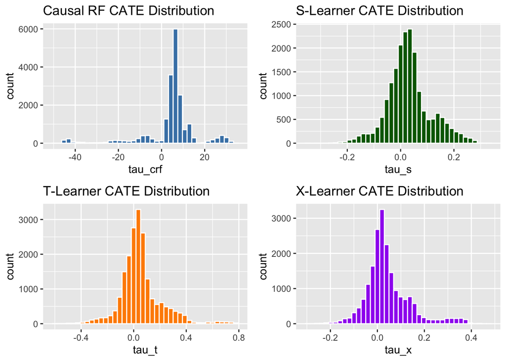

```r
# Learner Comparison histograms
res <- data.frame(
  tau_crf = CATE.FullSample,
  tau_s   = tau_s,
  tau_t   = tau_t,
  tau_x   = tau_x
)

p1 <- ggplot(res, aes(x = tau_crf)) +
  geom_histogram(bins = 40, fill = "steelblue", color = "white") +
  ggtitle("Causal RF CATE Distribution")

p2 <- ggplot(res, aes(x = tau_s)) +
  geom_histogram(bins = 40, fill = "darkgreen", color = "white") +
  ggtitle("S-Learner CATE Distribution")

p3 <- ggplot(res, aes(x = tau_t)) +
  geom_histogram(bins = 40, fill = "darkorange", color = "white") +
  ggtitle("T-Learner CATE Distribution")

p4 <- ggplot(res, aes(x = tau_x)) +
  geom_histogram(bins = 40, fill = "purple", color = "white") +
  ggtitle("X-Learner CATE Distribution")

grid.arrange(p1, p2, p3, p4, nrow = 2)
```

```r
# Summary table across all learners
learner_summary <- tibble(
  Learner     = c("Causal RF", "S-Learner", "T-Learner", "X-Learner"),
  Mean_CATE   = round(c(mean(res$tau_crf), mean(res$tau_s),
                         mean(res$tau_t),   mean(res$tau_x)), 5),
  Median_CATE = round(c(median(res$tau_crf), median(res$tau_s),
                          median(res$tau_t),   median(res$tau_x)), 5),
  SD_CATE     = round(c(sd(res$tau_crf), sd(res$tau_s),
                          sd(res$tau_t),   sd(res$tau_x)), 5)
)
cat("\n=== Learner Comparison: CATE Summary ===\n")
```

```
=== Learner Comparison: CATE Summary ===
```

```r
print(learner_summary)
```

```
# A tibble: 4 × 4
  Learner   Mean_CATE Median_CATE SD_CATE
  <chr>         <dbl>       <dbl>   <dbl>
1 Causal RF    4.56        6.31   12.2
2 S-Learner    0.0315      0.0251  0.0825
3 T-Learner    0.0535      0.0352  0.158
4 X-Learner    0.0432      0.0244  0.0950
```

## Findings

### 4.3 Summary of Key Results

#### Summary Code

```r
#SDiD ATT Estimate
cat("SDiD ATT:", round(as.numeric(tau.sdid), 4))
```

```
SDiD ATT: -0.0061
```

```r
#Causal Forest ATE
cf_ate <- average_treatment_effect(fullsample.forest)
cat("Causal Forest ATE:", round(cf_ate[1], 4), "SE:", round(cf_ate[2], 4))
```

```
Causal Forest ATE: NaN SE: NA
```

```r
#Comparison of Meta-Learners (Mean CATE)
print(learner_summary %>% select(Learner, Mean_CATE, SD_CATE))
```

```
# A tibble: 4 × 3
  Learner   Mean_CATE SD_CATE
  <chr>         <dbl>   <dbl>
1 Causal RF    4.56   12.2
2 S-Learner    0.0315  0.0825
3 T-Learner    0.0535  0.158
4 X-Learner    0.0432  0.0950
```